# 10. praktikum

18.03.2026

# Mittearvuliste tunnuste vahelised seosed

## Tänases praktikumis

- hii-ruut-test
- mitmese testimise probleem
- seose tugevuse hindamine
- testi võimsus
- Fisheri täpne test
- Monte-Carlo simulatsioon

## Hii-ruut-test

Hii-ruut-test on statistiline test, millega saab hinnata kahe kategoriaalse tunnuse sõltuvust. Test töötab **risttabeliga**, milles on lihtsagedused (mitte suhtelised ega normaliseeritud sagedused).

Tegelikult on hii-ruut-testid terve testide pere, mille arvutamiseks kasutatakse sama valemit, ent mis erinevad selle poolest, milline peab olema valim, mis on nullhüpotees ja kuidas testi tulemust tõlgendada.

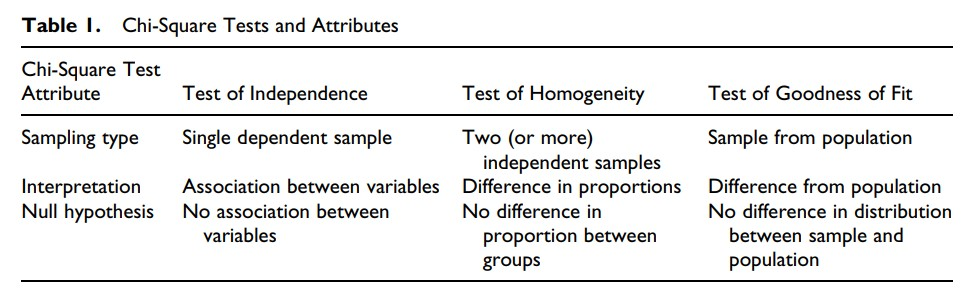

Franke, Todd Michael, Timothy Ho & Christina A. Christie 2012. [The Chi-Square Test: Often Used and More Often Misinterpreted.](https://www.researchgate.net/publication/258124458_The_Chi-Square_Test_Often_Used_and_More_Often_Misinterpreted) *American Journal of Evaluation* 33(3), 448-458.

**Kooskõlamäära testis** (*goodness of fit*) vaatleme mingi kategoriaalse tunnuse jaotumist ühes valimis ning testime, kas see valim võiks tulla populatsioonist, mille sama tunnuse jaotumise kohta on meil juba teadmine olemas. See testi liik on niisiis analoogne nt ühe valimiga t-testile, kus võrdleme valimi mingit arvulist näitajat (nt laste pikkused) populatsiooni omaga, otsustamaks, kui tõenäoline on, et valim on samast populatsioonist. Arvulise näitaja asemel on siin aga mingi kategoriaalse tunnuse väärtuste sagedused.

**Sõltumatuse testis** (*independence*) uurime kahe tunnuse vahelist seost samas valimis, **homogeensuse testis** (*homogeneity*) aga uurime, kas ühe tunnuse kategooriate proportsioonid on kahes sõltumatus valimis erinevad. See eristus võib aga kohati olla keeruline, kuna alati pole selge, mis hetkest peaks rääkima eraldi valimitest/gruppidest. Testi tegemine käib mõlemal juhul samamoodi, ent erinevused tulenevad valimi moodustamisest ja testi tõlgendamisest.

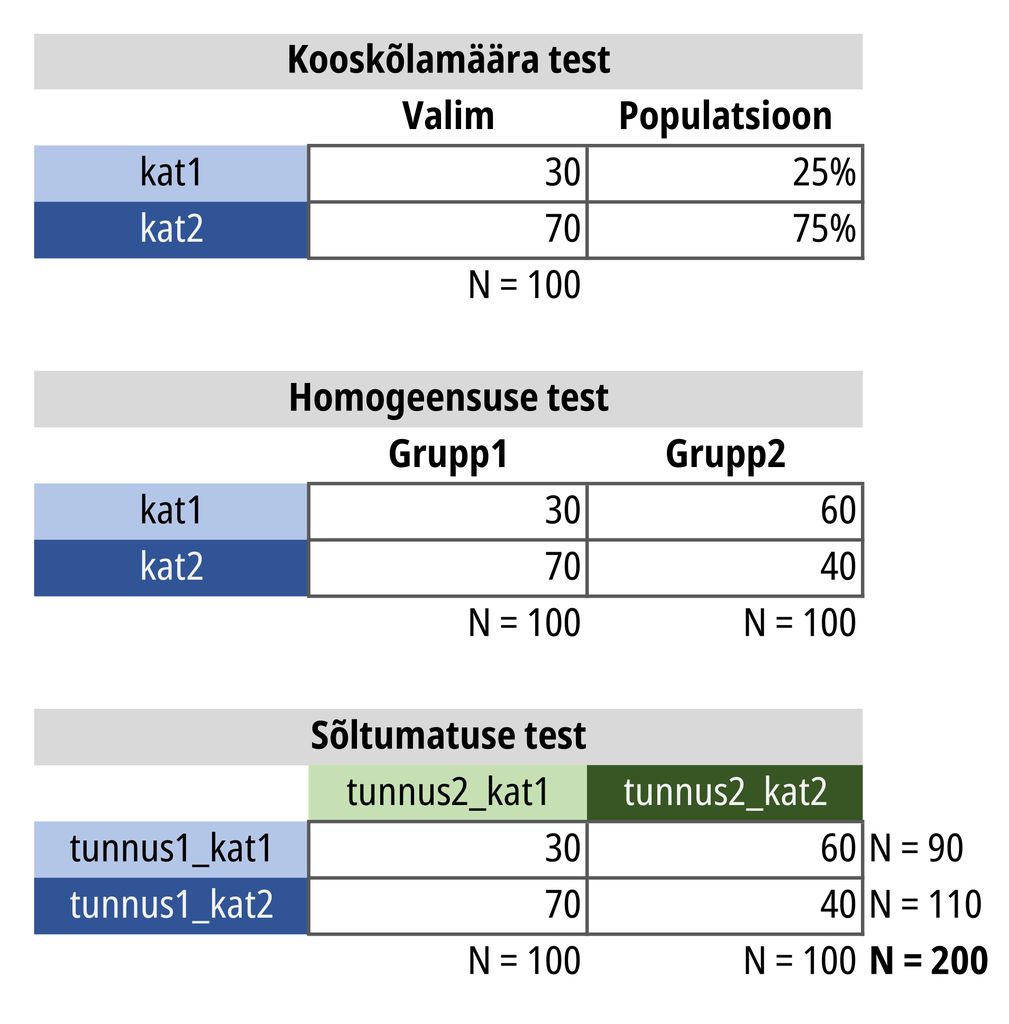

Selles praktikumis keskendume sõltumatuse testile, kus uurime kahe tunnuse omavahelise seose olemasolu: **kas ühe tunnuse väärtuste teadmine aitab ennustada teise tunnuse väärtust** (*chi-square test of independence*)?

### Andmed

#### Näide 1

Vaatleme näitena andmeid Ann Siimani artiklist [“Ainsuse sisseütleva vormi valiku seos morfosüntaktiliste ja semantiliste tunnustega - materjali ning meetodi sobivus korpusanalüüsiks”](http://www.kirj.ee/public/ESA/2015/esa_61_2015_207_232.pdf) (2015), kus ta kasutas hii-ruut-testi, et selgitada välja, millest sõltub sisseütleva käände kasutuses see, kas kasutatakse lühikest sisseütleva käände vormi ehk **aditiivi** (*majja*) või pikka sisseütleva käände vormi ehk **illatiivi** (*majasse*).

Uurime siin esmalt, kas vormi valik sõltub sellest, kas tegemist on pärisnime või üldnimega (nt *Tartusse* vs. *ajajärku*). Teeme seega sõltumatuse testi, kuna iga valimisse sattunud sõna kohta on kodeeritud kaks seda sõna iseloomustavat tunnust (sisseütleva vorm ja nimelisus).

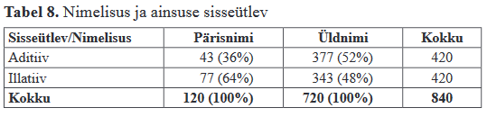

Siiman 2015: 220

```r
# Koostame artiklis esitatud andmete põhjal
# esmalt risttabeli.
tab <- matrix(c(43, 77, 377, 343), # koosesinemise sagedused
              ncol = 2, # mitmesse tulpa sagedused jaotada?
              dimnames = list(c("Lühike", "Pikk"), # tabeli ridade nimed
                              c("Pärisnimi", "Üldnimi"))) # tabeli tulpade nimed

tab
```

```
##        Pärisnimi Üldnimi
## Lühike        43     377
## Pikk          77     343
```

Kui meil oleks vormikasutuse kohta põhjalikum andmestik, saaks risttabelit saaks mõistagi teha ka andmestiku tunnustest, nt `table(andmed$tunnus1, andmed$tunnus2)`.

Kui esitatud näide sind ei kõneta, võid teha tabeli ka mõne muu uurimuse põhjal, kus risttabelites sagedusi on raporteeritud.

#### Näide 2

Annika Kängsepp (2024). [Käändevormide varieerumine ja seda mõjutavad tegurid kirjalikus keeles indefiniitpronoomeni *keegi* näitel](https://keeljakirjandus.ee/wp-content/uploads/2024/11/A.KANGSEPP.pdf). Keel ja Kirjandus 11, 1016-1037.

Normingupäraste (*NP*, nt *kellelgi*) ja norminguvastaste (*NV*, nt *kellegil*) käändevormide jagunemine vastavalt teksti žanrile

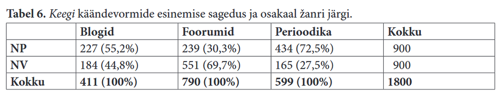

```r
tab <- matrix(c(227,184,239,551,434,165),
              ncol = 3,
              dimnames = list(c("NP", "NV"),
                              c("Blogid", "Foorumid", "Perioodika")))
```

#### Näide 3

Annaliisa Mäletjärv (2021). [Varjatud emotsioonide äratundmine näoväljendustest](https://sisu.ut.ee/wp-content/uploads/sites/561/maletjarv_annaliisa_uurimistoo.pdf). Uurimistöö.

Videoklippidele antud hinnangud väljendatud emotsioonide kohta (ridades) ning tegelikud (uurija poolt määratud) emotsioonid (tulpades)

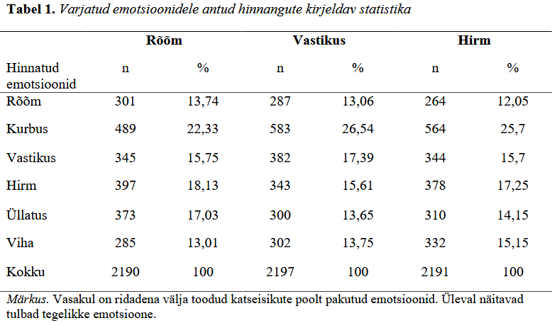

```r
tab <- matrix(c(301,489,345,397,373,285,
                287,583,382,343,300,302,
                264,564,344,378,310,332),
              ncol = 3,
              dimnames = list(c("Rõõm", "Kurbus", "Vastikus", "Hirm", "Üllatus", "Viha"),
                              c("Rõõm", "Vastikus", "Hirm")))
```

#### Näide 4

Pille Markov (2019). [Intellektuaalne ja visuaalne realism laste joonistustes](https://dspace.ut.ee/bitstreams/ff20444f-d980-44d2-9288-990b502aafbb/download). Uurimistöö.

Laste vanuserühmad ning valitud joonistamisstrateegia laste joonistuskatses

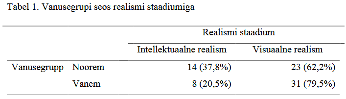

```r
tab <- matrix(c(14,8,23,31),
              ncol = 2,
              dimnames = list(c("Noorem", "Vanem"),
                              c("Intellektuaalne realism", "Visuaalne realism")))
```

#### Näide 5

Kai Tiitsaar (2010). [Hugo Treffneri Gümnaasiumi õpilaste käelisus](https://akadeemiake.ee/wp-content/uploads/2011/09/akadeemiake08.pdf#page=29). Akadeemiake 1(8), 29-50.

Käelisus poiste ja tüdrukute hulgas

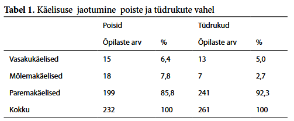

```r
tab <- matrix(c(15,18,199,13,7,241),
              ncol = 2,
              dimnames = list(c("Vasakukäelised", "Mõlemakäelised", "Paremakäelised"),
                              c("Poisid", "Tüdrukud")))
```

### Andmete visualiseerimine

Visualiseerime sagedusi.

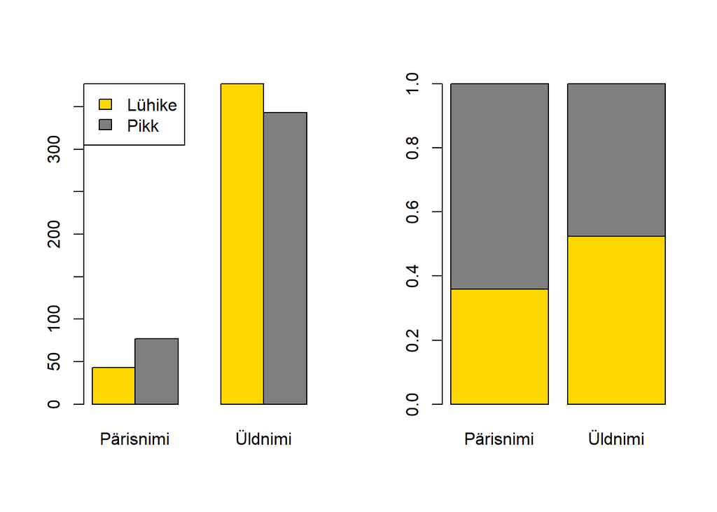

```r
par(mfrow = c(1, 2)) # näita jooniseid ühes reas kahes tulbas (= kõrvuti)
# esimene joonis:
barplot(tab, # sisendiks tavaline risttabel
        col = c("gold1", "grey50"),
        legend.text = rownames(tab), # legendi väärtused võta tabeli reanimedest
        beside = TRUE, # tulbad kõrvuti
        args.legend = list(x = "topleft")) # legend ülemisse vasakusse nurka

# teine joonis:
barplot(prop.table(tab, margin = 2), # sisendiks suhteliste sagedustega risttabel
        col = c("gold1", "grey50"))
```

```r
par(mfrow = c(1, 1)) # vii sätted uuesti algsele kujule
```

Kui meil on kasutada ainult sagedustabel (st meil pole algandmeid, kus ridades on vaatlused ja tulpades on tunnused, nt `vorm` ja `nimelisus`), siis peame ggploti kasutamiseks sagedustabeli esmalt `data.frame` tüüpi tabeliks teisendama.

```r
library(tidyverse)
df <- tab %>% # võtame table-tüüpi objekti
  as.data.frame() %>% # teisendame selle data.frame-tüüpi objektiks
  rownames_to_column(var = "Vorm") %>% # paneme reanimed tulpa "Vorm"
  pivot_longer(cols = c("Pärisnimi", "Üldnimi"), # teeme laiast tabelist "pika", nii et võtame pärisnime ja üldnime tulbad,
               names_to = "Liik", # paneme need tulbanimed ("Pärisnimi", "Üldnimi") pika tabeli tulpa "Liik"
               values_to = "Sagedus")
```

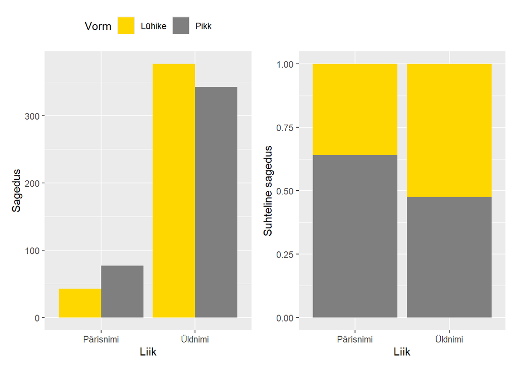

```r
# esimene joonis:
ggplot(df) +
  geom_col(aes(x = Liik, y = Sagedus, fill = Vorm), position = "dodge") +
  scale_fill_manual(values = c("gold1", "grey50")) +
  theme(legend.position = "top") -> p1

# teine joonis:
ggplot(df) +
  geom_col(aes(x = Liik, y = Sagedus, fill = Vorm), position = "fill", show.legend = F) +
  scale_fill_manual(values = c("gold1", "grey50")) +
  labs(y = "Suhteline sagedus") -> p2

# kuva jooniseid kõrvuti
# install.packages("patchwork")
library(patchwork)
p1 + p2
```

### Tegelikud ja oodatud sagedused

Hii-ruut-test põhineb tegelike ja teoreetiliste sageduste võrdlemisel.

**Tegelikud/vaadeldud** (*Observed*) sagedused on tegelikud sagedused igas tabeli lahtris (nt 43, 77 jne).  
**Teoreetilised/oodatud** (*Expected*) sagedused leitakse valemiga `reasumma*veerusumma/kogusumma`.

Teoreetilised sagedused väljendavad kahe tunnuse kategooriate koosesinemiste sagedusi nullhüpoteesi korral ehk juhul, kui kahe vaadeldava tunnuse erinevad väärtused esineksid koos täiesti juhuslikult ning nende kasutuses ei esineks mingeid mustreid ega seoseid. Sellisel juhul peaks saama tabeli lahtrite väärtused tuletada puhtalt ridade ja veergude kogusagedustest: kui üht kategooriat (nt üldnimesid) esineb andmestikus rohkem, esineb teda ühtviisi rohkem nii lühikeste kui ka pikkade sisseütleva vormide korral.

Mida suurem on tegelike sageduste erinevus teoreetilistest sagedustest, seda suurem on ka hii-ruut-statistiku väärtus.

```r
(tab_margins <- addmargins(tab)) # lisame tabelile rea- ja veerusummad
```

```
##        Pärisnimi Üldnimi Sum
## Lühike        43     377 420
## Pikk          77     343 420
## Sum          120     720 840
```

```r
# Näiteks lühikese sisseütlevaga pärisnimede (kuhu? - Tartu) teoreetiline sagedus oleks
# (reasumma*veerusumma/kogusumma)
tab_margins["Lühike","Sum"]*tab_margins["Sum","Pärisnimi"]/tab_margins["Sum","Sum"]
```

```
## [1] 60
```

Teoreetilisi sagedusi ei pea aga ise käsitsi arvutama, need saab kätte ka hii-ruut-testi väljundist.

```r
chisq.test(tab)$expected # teoreetilised sagedused
```

```
##        Pärisnimi Üldnimi
## Lühike        60     360
## Pikk          60     360
```

### Hii-ruut-testi eeldused

- Valim on üldkogumist juhuslikult valitud.
- Vaatlused on sõltumatud.
- Iga vaatlus peab sobima risttabelis täpselt ainult ühte lahtrisse (st iga uuritava tunnuse ainult ühte kategooriasse).

Uuritava andmestiku puhul ei ole tegelikult vaatluste sõltumatuse nõue täidetud, kuna korpuses ei ole igalt kõnelejalt ainult üks mingi sisseütlevas käändes sõna kasutuskord. See tähendab, et kõneleja/kirjutaja, kes on rohkem sisseütlevas käändes sõnu tarvitanud, mõjutab enam ka testi tulemusi. Keelekorpustega, kus pahatihti on ka keeruline tuvastada, kes täpselt kõneleja/kirjutaja on, vaatluste sõltumatuse nõuet sageli eiratakse, ent sellisel juhul võib alati küsida, kas ikka kirjeldame keelt üldiselt või mõne domineeriva keelekasutaja idiolekti.

Sageli viidatakse hii-ruut-testi eeldusena ka nn Cochrani reeglile, mille põhjal ei tohiks hii-ruut-testi tegemisel olla **oodatud sageduste hulgas 5st väiksemaid väärtusi enam kui 20% lahtrites** ning **ükski oodatud sagedus ei tohiks olla väiksem kui 1**. Nendele tingimustele on esitatud ka mööndusi, eriti keeleteaduses (nt [Stefanowitsch 2020](https://langsci-press.org/catalog/book/148): 177 või [Wallis 2021](https://www.routledge.com/Statistics-in-Corpus-Linguistics-Research-A-New-Approach/Wallis/p/book/9781138589384): 117), kuna reeglit peetakse liiga konservatiivseks. Klassikaliselt soovitatakse siiski sellistel juhtudel kasutada mõnd muud sarnast testi, nt [Fisheri testi või G-testi](https://kvanthum.github.io/10-mittearvuliste_seosed.html#fisheri-t%C3%A4pne-test-ja-g-test).

**R-is annab hii-ruut-test annab hoiatuse juba siis, kui kuskil oodatud sageduste hulgas on väärtusi < 5.**

### Hii-ruut-test

Sõnastame hüpoteesid.

**H0**: Sõna nimelisus ja tema sisseütleva käände vorm on teineteisest sõltumatud tunnused ja ühe tunnuse väärtuse teadmine ei aitaks ennustada teise tunnuse väärtust (tabeli lahtrites olevad väärtused on tuletatavad tabeli marginaalsagedustest).  
**H1**: Sõna nimelisus ja sisseütleva käände vorm on teineteisest sõltuvad tunnused ja ühe tunnuse väärtuse teadmine aitab ennustada teise tunnuse väärtust (tabeli lahtrites olevad väärtused ei ole tuletatavad tabeli marginaalsagedustest).

Teeme nüüd päriselt hii-ruut-testi.

```r
chisq.test(tab, correct = FALSE)
```

```
##
##  Pearson's Chi-squared test
##
## data:  tab
## X-squared = 11.239, df = 1, p-value = 0.000801
```

Hii-ruut-statistik leitakse valemiga $x^2 = \sum \frac{(o-e)^2}{e}$, kus *o* (*observed*) on tegelik sagedus ja *e* (*expected*) on teoreetiline sagedus. See tähendab, et iga risttabeli lahtri sagedusest lahutatakse selle teoreetiline sagedus (`o-e`), saadud tehte tulemused võetakse ruutu (`(o-e)^2`), ruutu võetud erinevused jagatakse läbi lahtrite teoreetiliste sagedustega (`(o-e)^2/e`) ning kõik selle tulemusel lahtritesse saadud väärtused liidetakse kokku.

```r
# salvestame testi tulemuse objekti
t <- chisq.test(tab, correct = FALSE)

# leiame hii-ruut-statistiku käsitsi
sum(((t$observed - t$expected)^2)/t$expected)
```

```
## [1] 11.23889
```

Mida suurem erinevus tegelike ja oodatud sageduste vahel on, seda suurem on **statistiku** väärtus, ehkki **konkreetne väärtus sõltub oluliselt marginaalsagedustest**.

Kuna *p*-väärtus on siin väga väike (`0.000801`), on väga väike tõenäosus (täpsemalt 0,0801%), et valimis täheldatud erinevused oodatud ja tegelike sageduste vahel on juhuslikud ja esineksid ka siis, kui tegelikult kehtiks nullhüpotees ja seost kahe tunnuse vahel ei oleks. Seega on alust nullhüptees hüljata ja võtta vastu sisukas hüpotees, mille kohaselt kaks tunnust on omavahel sõltuvuses.

Kasutasime praegu testi tegemisel argumenti `correct = FALSE`. Vaikimisi tehakse R-is 2x2 tabelite puhul test nn **Yatesi pidevusparandusega** (*Yates’ continuity correction*). Pidevusparanduse käigus lahutatakse iga lahtri sageduse ja selle oodatud sageduse vahe absoluutväärtusest veel 0,5. Nii väheneb hii-ruut-statistiku väärtus ja suureneb *p*-väärtus. Tegemist on niisiis pisut konservatiivsema taktikaga, mida võiks rakendada juhul, kui 2x2 tabelis on mõni teoreetiline sagedus < 5.

```r
chisq.test(tab)
```

```
##
##  Pearson's Chi-squared test with Yates' continuity correction
##
## data:  tab
## X-squared = 10.587, df = 1, p-value = 0.001139
```

Pidevusparanduse käigus muutuvad ainult statistik ja *p*-väärtus, oodatud sagedusi ja jääke pidevusparanduse kasutamine kuidagi ei mõjuta.

Pane tähele, et kahe tunnuse sõltuvust testival hii-ruut-testil on **vabadusastmete arv** enam mitte üks vähem kui vaatluste arv, vaid (ridade arv - 1) * (tulpade arv - 1). Vabadusastmed iseloomustavad siin nende risttabeli lahtrite arvu, mille väärtusi saaks vabalt muuta, ilma et ridade ja tulpade marginaalsagedused või üldine sageduste summa muutuks. 2x2 risttabelis on selliseid lahtreid ainult 1, sest kohe, kui oleme ühte lahtrisse mingi sageduse kirjutanud, on teiste lahtrite sagedused marginaalsageduste põhjal juba ette kindlaks määratud.

Testi *p*-väärtus näitab niisiis, kui tõenäoline on selle vabadusastmete arvu ja määratud olulisusnivoo korral (nt df = 1, alfa = 0.05), et saaksime sellise hii-ruut-statistiku ka siis, kui kahe tunnuse vahel poleks tegelikult mingit seost. Hii-ruut-jaotuse kriitilisi väärtusi, millest alates saame lugeda seose oluliseks, saab vaadata vastavatest tabelitest, nt [siit](https://people.richland.edu/james/lecture/m170/tbl-chi.html).

Tuleb aga silmas pidada, et mida suurem on vabadusastmete arv ehk mida rohkem kategooriaid kahel tunnusel kokku on, seda tõenäolisemalt hii-ruut-test sealt mõne olulise seose tuvastab. Samuti kipuvad andmed sellistes tabelites kategooriate vahel hajuma ning tegelike sageduste hulka satub palju nulle. Seepärast **ei soovitata teha hii-ruut-testi suurtel tabelitel, kus on palju ridu ja/või tulpasid**.